```python
%matplotlib inline
import matplotlib.pyplot as plt
import numpy as np
import scipy
```

```python
import seaborn as sns
#sns.set()
sns.set(color_codes=True)
```

# Probability theory

## Introduction via sampling

The simplest way to introduce the basic notions of probability theory as you would encounter them in ML is via samples. For the most common **coin tossing** scenario, you wish to generate a sample of 10 tosses of a coin, with a probability of getting a head (1) of 0.7.

```python
np.random.binomial(1,.7,10) # biased coin p = 0.7
```

```
array([1, 0, 1, 0, 1, 0, 1, 1, 1, 1])
```

If you toss a coin 10 times and count the number of heads, you will run the following:

```python
np.random.binomial(10,.7,1)
```

```
array([10])
```

If you wish to simulate tossing a coin 10 times, counting the number of heads, and repeating the experiment 5 times, do:

```python
np.random.binomial(10,.7,5)
```

```
array([7, 6, 7, 7, 6])
```

#### In probability theory we study the properties of data obtained by a generative process. In (probabilistic) machine learning, we infer properties of the generative process from the data seen.

- You will see in this lab that several of the exercises involve calculating means and variances of samples, but the samples are generated in several replicates. This is a simulation of the fact that when we obtain data from the world, what we see is a sample that could vary depending on circumstance and observation method. Repeat measurements are made in real experiments in controlled circumstances. In machine learning, we hoover up data from many uncontrolled, observational settings; hence, it is likely that on another occasion the characteristics of another representative data set might be similar statistically, but vary in the particulars of each sample point. This is why we repeat the experiments of taking sample sequences.
- Repeat the same experiment of tossing a coin 10 times (or tossing 10 identical coins) 10000 times and display the results as a histogram. A histogram is a common way of visualising the spread of values one obtains for the **values** of a **random variable**. Commonly, upper case letters $X$ denote **variables** and lower case letters $x_1, x_2, \ldots $ denote **values** taken by the variables. $P(X)$ is the distribution of values of the variable, while $P(X=x_1)$ is the probability that the variable $X$ takes the value $x_1$.

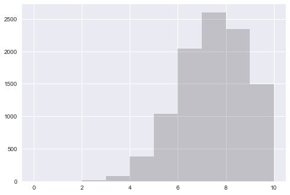

```python
x=np.random.binomial(10,.7,10000) # biased coin p = 0.7
ls = [i for i in range(11)]

plt.hist(x,color='k',alpha=0.2,bins=ls)
```

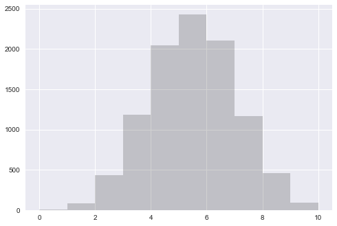

```python
x=np.random.binomial(10,.5,10000) # unbiased coin p = 0.5
ls = [i for i in range(11)]

plt.hist(x,color='k',alpha=0.2,bins=ls)
```

One of the most useful theorems you will need to know (not necessarily prove!) is the **Central Limit Theorem** (CLT) [https://en.wikipedia.org/wiki/Central_limit_theorem] (for a proof, see [http://mathworld.wolfram.com/CentralLimitTheorem.html]). Its role in machine learning is to find a systematic way of treating errors. We usually make up a model to capture regularities in data, and the fit is imperfect. The true values are an outcome of many contributory factors in the generative process that our model only approximately summarises the effects of. The accumulation of the mismatches at each target observation is what the CLT models. The relationship between modelling errors (in the least squares example) and the distribution of errors goes back to Gauss, hence the name.

We start with a collection of $N$ random numbers $x_k$, $k=1,\ldots,N$ that are the values taken by a random variable $X$. Their mean \begin{equation} \langle X \rangle_{N}=\frac{1}{N}\sum_{k=1}^N x_k \end{equation} is also a random variable. If a sample of $N$ random numbers is chosen $S$ times, each of the $S$ samples will have a different mean, which we can call $$\langle X \rangle_{N}^{(s)}, \; s=1,\ldots,S.$$ (The *notation* uses $(i)$ in superscripts to identify the $i$th sample.) These numbers $\langle x\rangle_N^{(s)}$ form a limiting distribution when $N\rightarrow \infty$. This tendency of the means of samples is called the **Central Limit Theorem**. If the samples are drawn from a population with a mean of $\mu$ and a standard deviation of $\sigma$, then the mean of the sample means coincides with the population mean, and the standard deviation of the sample means diminishes as the inverse square-root of $N$: $$\lim_{N\rightarrow\infty}\frac{1}{S}\sum_{s=1}^S\langle x \rangle_N^{(s)} = \mu, \;\mbox{ and }\; \lim_{N\rightarrow\infty}\frac{1}{S}\sum_{s=1}^S\left(\langle x\rangle_N^{(s)} - \mu\right)^2 = \frac{\sigma^2}{N}.$$ $$\mbox{For a sample size $N$, the standard deviation of sample means is } \frac{\sigma}{\sqrt N} .$$
**You must remember this $\frac{1}{\sqrt{N}}$ dependence.**

### CLT: Sampling from a uniform distribution

Uniform distribution from the range $a\leq x \leq b$ is obtained by calling

- r = np.random.random()
- x = (b - a)*r + a

The first two moments of the distribution are $$\mbox{ mean } \frac{(a+b)}{2} \; \mbox{and variance } \frac{(b-a)^2}{12}. $$

##### Exercise:

Prove the above statements rewritten mathematically below with $p(x) dx = f^U_{[a,b]}(x)dx$ being the uniform distribution. (Check that $\int p(x) dx = 1$.) I try to stick using the symbols $\langle \cdot \rangle$ while others also use $\bar{\cdot}$ to denote sample means. \begin{equation} \begin{array}{ccc} \langle x \rangle&=&\displaystyle \int_a^b x p(x)dx = \frac{(a+b)}{2}\\ \langle (x-\langle{x}\rangle)^2 \rangle &=&\displaystyle \int_a^b (x-\langle{x}\rangle)^2 p(x)dx = \frac{(a-b)^2}{12} \end{array} \end{equation}

```
ranblock0 has shape:  (900, 100) ranblock1 has shape:  (900, 100000)
(S,N) denotes N repeats of sequences of length S
The 4 histograms show the distribution of S uniform random numbers between 3 and 5.
The range [3,5] has been divided into 10 bins, each of which contain 90 points on average.
```

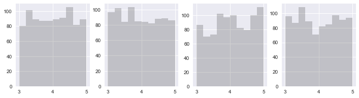

```python
# Central Limit Theorem for binary sequences of length 10 and 30
# Each such sequence is a random variable with a mean that is also a random variable
# The distribution of these means converges to a well-defined distribution
# The mean becomes more accurate as the length of the sequence increases
# The mean for sequence length 30 is more accurate (smaller spread of values)

# IMPLEMENTATION STRATEGY: generate LONGEST sequence ("seqlen[-1]" below)
# using a random number function call "np.random.random"
# Take SUBSEQUENCES of the longest sequence to compute means from:
# "ranblock0[:s**2] for s in enumerate(sig)"

nreps = [10**2, 10**5]
sig = [10,20,30]
seqlen = [i**2 for i in sig]  # length of sequences
ranblock0=2*np.random.random((seqlen[-1],nreps[0])) + 3 # uniform random numbers between 3 and 5
ranblock1=2*np.random.random((seqlen[-1],nreps[1])) + 3
fig, ax = plt.subplots(nrows=1, ncols=4, figsize=(12,3))
ax[0].hist(ranblock0[:,0],color='k',alpha=0.2)
ax[1].hist(ranblock0[:,-1],color='k',alpha=0.2)
ax[2].hist(ranblock1[:,0],color='k',alpha=0.2)
ax[3].hist(ranblock1[:,-1],color='k',alpha=0.2)
print("ranblock0 has shape: ", ranblock0.shape, "ranblock1 has shape: ", ranblock1.shape)
print("(S,N) denotes N repeats of sequences of length S")
print("The 4 histograms show the distribution of S uniform random numbers between 3 and 5.")
print("The range [3,5] has been divided into 10 bins, each of which contain 90 points on average.")
```

For each of these sequences of 900 numbers we shall calculate the mean. We would expect a value close to 4, but owing to the stochastic nature of the sequences we are averaging over, the actual value will be scattered around 4. How variable is the distribution around the mean?

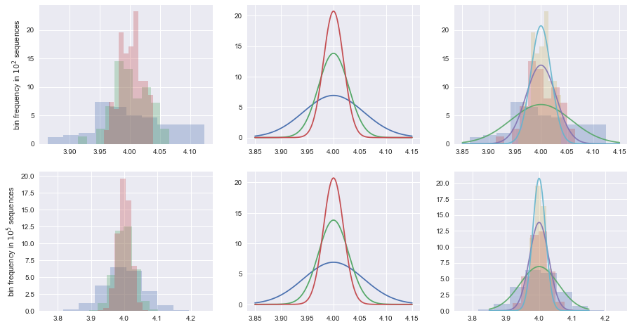

```python
xv=np.linspace(3.85,4.15,1000) # appropriate x-axis limits
def gaussianvec(x, slen, p):
    mu = p # mean is the same as that of the Bernoulli generating dist
    sig = np.sqrt(4/(12*slen)) # s.d.
    return np.asarray(np.exp(-(x-mu)**2/(2*sig**2))/(np.sqrt(2*np.pi)*sig))
fig, ax = plt.subplots(nrows=2,ncols=3,figsize=(15,8))
for i, s in enumerate(sig):
    ax[0][0].hist(np.mean(ranblock0[:s**2],axis=0),alpha=0.3,normed=True)
    ax[0][1].plot(xv,gaussianvec(xv, s**2,4))
    ax[0][2].hist(np.mean(ranblock0[:s**2],axis=0),alpha=0.3,normed=True)
    ax[0][2].plot(xv,gaussianvec(xv, s**2,4),alpha=0.9)
    ax[1][0].hist(np.mean(ranblock1[:s**2],axis=0),alpha=0.3,normed=True)
    ax[1][1].plot(xv,gaussianvec(xv, s**2,4))
    ax[1][2].hist(np.mean(ranblock1[:s**2],axis=0),alpha=0.3,normed=True)
    ax[1][2].plot(xv,gaussianvec(xv, s**2,4),alpha=0.9)
    ax[1][0].set_ylabel(r'bin frequency in $10^5$ sequences')
    ax[0][0].set_ylabel(r'bin frequency in $10^2$ sequences')
```

### CLT: The coin tossing example

Toss a coin $N$ times, with probability $p$ of getting heads, $q=1-p$ of getting tails. This is modelled as a binomial distribution. The probability of obtaining $k$ heads after $N$ tosses of such a coin is
$$P(k)=\left(N\atop k\right)p^k q^{N-k},\; k=0, \ldots, N. $$ The first two central moments are $$\mbox{ mean } Np \; \mbox{and variance } Npq.$$ Each sample sequence is a random variable with a mean that is also a random variable. The mean and variance of the sample means is what we can eyeball in the histograms below. The histograms suggest that the distribution of these sample means converges to a well-defined distribution, with the sample variances becoming smaller as the sequence length in increased. Thus, the mean becomes more accurate as the length of the sequence is increased.

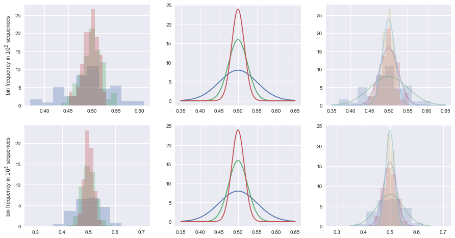

```python
# Central Limit Theorem for binary sequences of length 10 and 30
# The mean for sequence length 30 is more accurate (smaller spread of values)
# Same simulation strategy as above

nreps = [10**2, 10**5]
sig = [10,20,30]
seqlen = [i**2 for i in sig]
ranblock0=np.random.binomial(1,.5,(seqlen[-1],nreps[0])) # generating longest sequence
ranblock1=np.random.binomial(1,.5,(seqlen[-1],nreps[1])) # subsequences used below

xv=np.linspace(0.35,0.65,1000)
def gaussianvec(x, slen, p):
    mu = p # mean is the same as that of the Bernoulli generating dist (binomial)
    sig = np.sqrt(p*(1-p)/slen) # s.d. of binomial = sqrt(N*p*q)/N
    return np.asarray(np.exp(-(x-mu)**2/(2*sig**2))/(np.sqrt(2*np.pi)*sig))
fig, ax = plt.subplots(nrows=2,ncols=3,figsize=(15,8))
for i, s in enumerate(sig):
    ax[0][0].hist(np.mean(ranblock0[:s**2],axis=0),alpha=0.3,normed=True)
    ax[0][1].plot(xv,gaussianvec(xv, s**2,0.5))
    ax[0][2].hist(np.mean(ranblock0[:s**2],axis=0),alpha=0.2,normed=True)
    ax[0][2].plot(xv,gaussianvec(xv, s**2,0.5),alpha=0.4)
    ax[1][0].hist(np.mean(ranblock1[:s**2],axis=0),alpha=0.3,normed=True)
    ax[1][1].plot(xv,gaussianvec(xv, s**2,0.5))
    ax[1][2].hist(np.mean(ranblock1[:s**2],axis=0),alpha=0.2,normed=True)
    ax[1][2].plot(xv,gaussianvec(xv, s**2,0.5),alpha=0.4)

    ax[1][0].set_ylabel(r'bin frequency in $10^5$ sequences')
    ax[0][0].set_ylabel(r'bin frequency in $10^2$ sequences')
```

### Something to think about

- The occurrence of male/female births are recorded in all hospitals. In a hospital in a remote area there are fewer births than one in a densely populated city. Relate your experience with the coin tossing example to estimate how much a deviation from a 50:50 ratio of male:female births in each hospital would be considered anomalous.
- You have a classifier that makes errors in classification on a dataset gathered from a human population that are tagged according to standard race, age, gender categories. In a **fair ML** system, the rate of misclassification (say, an incorrect labelling of who commits a crime, or who is considered unsuitable for a job) should be the same across all sub-populations. It is your job to monitor these errors of classification in job applications to indentify potential gender bias. How might you devise metrics to track potential bias?

## Multivariate Distributions

For a $p$-dimensional variable $\mathbf{X}$, the values it can take are $(x_1,\ldots,x_p)$, where $x_i$ are discrete labels, names. For $p=6$, we can consider a loaded die with each numbered die face associated with one of the $p=6$ labels. If you sample this variable $N$ times, you throw this die $N$ times you get a sequence of the form \begin{equation} \begin{array}{ccccc} x^{(1)}&x^{(2)}&x^{(3)}&\cdots&x^{(N)}\\ 1&6&2&\cdots&6\\ \end{array} \end{equation}

For a random vector $$\boldsymbol{X}=\left(\begin{array}{c}X_1\\\vdots\\X_p\end{array}\right) $$ the population **mean**, or **expectation**, is written $\mathbb{E}[\boldsymbol{X}]$ $$\boldsymbol{\mu} = \left(\begin{array}{c}\mu_1\\\vdots\\\mu_p\end{array}\right) = \mathbb{E}[\boldsymbol{X}]= \left(\begin{array}{c}\mathbb{E}[X_1]\\\vdots\\\mathbb{E}[X_p]\end{array}\right), $$ and the **variance-covariance matrix** $\boldsymbol{\Sigma}$ is $$ \boldsymbol{\Sigma}=\mathbb{V}[\boldsymbol{X}]=\left(\begin{array}{cccc} \mathbb{V}[X_1]&\mathsf{Cov}[X_1,X_2]&\cdots&\mathsf{Cov}[X_1,X_p]\\ \mathsf{Cov}[X_2,X_1]&\mathbb{V}[X_2]&\cdots&\mathsf{Cov}[X_2,X_p]\\ \vdots&\vdots&\ddots&\vdots\\ \mathsf{Cov}[X_p,X_1]&\mathsf{Cov}[X_p,X_2]&\cdots&\mathbb{V}[X_p] \end{array} \right), $$ where $$\mathbb{V}[X_i]\triangleq \mathbb{E}\left[(X_i-\mathbb{E}[X_i])^2\right] = \mathbb{E}\left[(X_i-\mu_i)^2\right],\mbox{ and } \mathsf{Cov}[X_i,X_j] = \mathbb{E}\left[(X_i-\mathbb{E}[X_i])(X_j-\mathbb{E}[X_j])\right]. $$

**The loaded dice example**

Rolling a cubic die $N$ times with a probability $p_i$ of obtaining $i=1,\dots,6$. You can look up the help on generating samples from a **multinomial distribution** Let $x^{(k)}$ be the outcome of the $k$-th throw of a die, $x^{(k)}\in\{1,\ldots,6\}$. The probability of occurrence of the outcomes $(x^{(1)}, \ldots, x^{(k)}, \ldots, x^{(N)})$ of $N$ rolls of a die can be summarised by the probabilities of the number of times the die-face $i$ shows up ($n_i$), for each of $i=1,\ldots,6$ with $n_1+\cdots+n_6=N$: \begin{equation} P_{\scriptstyle d}(\{x^{(k)}\}_k|\{\theta_i\}_i)=P_{\scriptstyle d}(n_1, \ldots, n_6|\{\theta_i\}_i)=\left(\frac{N!}{n_1! n_2! n_3! n_4! n_5! n_6!}\right) \theta_1^{n_1} \theta_2^{n_2}\theta_3^{n_3}\theta_4^{n_4}\theta_5^{n_5} \theta_6^{n_6}, \end{equation} $n_j$ counts occurrences of $j$. This can also be expressed more compactly as follows. The sample $(x^{(1)}, \ldots, x^{(k)}, \ldots, x^{(N)})$ of size $N$ drawn from a multinomial distribution is written as $\boldsymbol{X}\sim\mbox{Multinomial}(N,\boldsymbol{\theta})$, with probability \begin{equation} P_{\scriptstyle d}(\boldsymbol{X}|\boldsymbol{\theta})=P_{\scriptstyle d}(n_1, \ldots, n_6|\boldsymbol{\theta})=N! \prod_{j=1}^6\left(\frac{\theta_j^{n_j}}{n_j!}\right). \end{equation}

## Properties of the multinomial distribution

For a $p$-variate discrete variable (a variable that takes $p$ different values, like a $p$-sided die), the probability of occurence of each of the $p$ values is $$ \boldsymbol{\theta} = (\theta_1,\ldots,\theta_p).$$

- **Notation**: A multivariate sample $\boldsymbol{X}$ drawn from a probability distribution $\mathcal{P}$ is written $$\boldsymbol{X}\sim \mathcal{P}.$$

A multinomial sample of size $N$ with probability parameter $\boldsymbol{\theta}$, $\boldsymbol{X}\sim\mbox{Multinomial}(N,\boldsymbol{\theta})$ has $${\bf mean }\; \mathbb{E}[\boldsymbol{X}] = N \boldsymbol{\theta} = N(\theta_1, \theta_2,\ldots, \theta_p)^T$$ and $${\bf variance}\; \mathbb{V}[\boldsymbol{X}]=\left(\begin{array}{cccc} N\theta_1(1-\theta_1)&-N\theta_1\theta_2&\cdots&-N\theta_1\theta_p\\ -N\theta_2\theta_1&N\theta_2(1-\theta_2)&\cdots&-N\theta_2\theta_p\\ \vdots&\vdots&\ddots&\vdots\\ -N\theta_p\theta_1&-N\theta_p\theta_1&\cdots&N\theta_p(1-\theta_p) \end{array} \right)$$

**Proof**: If you focus on any one of the outcomes, say 1 (think: getting a 1 upon rolling a die), its probability of occurrence is $\theta_1$ and that of its non-occurrence is $(1-\theta_1)$ (think: getting a 2 or 3 or ... or 6). The mathematical way of stating this is that the **marginal distribution** of $X_1$ is a binomial distribution. The **marginal distribution** of $X_i$ is obtained from the **joint distribution** of the multivariate distribution $P(X_1, \ldots, X_i, \ldots, X_p)$ by summing over the probabilities of the values taken by all other variables:

$$P(X_i)=\displaystyle\sum_{\scriptstyle k=1\atop \scriptstyle k\neq i}^p P(\{X_k\}) \Leftrightarrow P(X_i=x_i) = \sum_{x_1\in X_1}\cdots\sum_{x_{i-1}\in X_{i-1}}\sum_{x_{i+1}\in X_{i+1}}\cdots\sum_{x_p\in X_p} P(X_1=x_1, \ldots, X_i=x_i, \ldots, X_p=x_p).$$

For the multinomial case, for $\boldsymbol{X}=(X_1,X_2,\ldots,X_p)\sim\mbox{Multinomial}(N,\boldsymbol{\theta})$, $X_1\sim\mbox{Binomial}(N,\theta_1)$. This is true for the marginal distribution for any $i$:$X_i\sim\mbox{Binomial}(N,\theta_i)$. Thus, the mean $\mathbb{E}[X_i]=N\theta_i$ and variance $\mathbb{V}[X_i]=N\theta_i(1-\theta_i)$.

For the variance, we will need a general result: for any two random variables $Y,Z$ $$\mathbb{E}[Y+Z]=\mathbb{E}[Y]+\mathbb{E}[Z]$$ and $$\mathbb{V}[Y+Z] = \mathbb{E}[\left(Y+Z - \mathbb{E}[Y+Z]\right)^2] = \mathbb{V}[Y] + \mathbb{V}[Z] + 2\mathsf{Cov}[Y,Z].$$

### Exercise: generate a multinomial sample

You can generate sequences of die faces by using the multinomial random number generator in **numpy**. Here is how you find out how to -- simply type "np.random.multinomial?"

Define a new variable as the sum of two variables for a finite sample. Verify for that sample the result stated above: $$\mathbb{V}[Y+Z] = \mathbb{V}[Y] + \mathbb{V}[Z] + 2\mathsf{Cov}[Y,Z].$$ You may use the **numpy** functions np.var() and np.cov(). Note, however that there is a difference between np.cov() and np.var(). In both, the numerator is the sum of squared deviations from the mean. However, for sample size $N$ the denominator is $N$ for np.var() and $N-1$ for np.cov(). This is the difference between a biased and unbiased estimator. Explore the difference.

### Numpy experiments with basic statistics

I will ask you to experiment with numpy to get the means and variances along the correct rows and columns. Explore how covariances are returned -- contrast biased and unbiased estimators. Use this to confirm that the means and variances of a sum of random variables can be expressed in terms of means and covariances as claimed.

```python
# Generate a multinomial sample
ns=6
probvec=(.2,.3,.1,.4)
a=np.random.multinomial(20,probvec,size=ns)
print("a contains results from 20 samples :\n", a)
```

```
a contains results from 20 samples :
 [[ 4  4  2 10]
 [ 6  8  2  4]
 [ 4  6  1  9]
 [ 6  5  3  6]
 [ 3  7  3  7]
 [ 4  4  4  8]]
```

```python
# Means and variances along different axes
[a0,a1,a2,a3,a01]=[a[:,0],a[:,1],a[:,2],a[:,3],a[:,0]+a[:,1]]
print("means: ",a0.mean(),a1.mean(),a2.mean(),a3.mean())
print("means with axis 0 call: \n", np.mean(a,axis=0))
print("variances with axis 0 call :\n ", np.var(a,axis=0))
print("variances:\n", a0.var(),a1.var(),a2.var(), a3.var())
print("mean squared dev:\n", np.sum(np.square(a-np.mean(a,axis=0)),axis=0)/ns)
```

```
means:  4.5 5.66666666667 2.5 7.33333333333
means with axis 0 call:
 [ 4.5         5.66666667  2.5         7.33333333]
variances with axis 0 call :
  [ 1.25        2.22222222  0.91666667  3.88888889]
variances:
 1.25 2.22222222222 0.916666666667 3.88888888889
mean squared dev:
 [ 1.25        2.22222222  0.91666667  3.88888889]
```

```python
# Biased and unbiased estimators from np.var() and np.cov()
print("np.cov(a0): ",np.cov(a0), "np.var(a0): ",np.var(a0))
# UNBIASED estimator of var = (sum of squared deviations/(ns-1)).
# Hence we scale np.var to get a match with result from np.cov
# np.cov returns UNBIASED estimator.  Look up <np.cov?>
print(np.cov(a0),(ns/(ns-1))*np.var(a0))
```

```
np.cov(a0):  1.5 np.var(a0):  1.25
1.5 1.5
```

```python
# Compare covariance of a0 and a1, np.cov(a0.T,a1.T), with that of a01=a0+a1
# Evaluate (0.5*/(ns/(ns-1)))*(var(a01)-(var(a0)+var(a1)))
# Compare the result with off-diagonal element of np.cov() between a0 and a1.
print(0.5*(ns/(ns-1))*(a01.var()-a0.var()-a1.var()))
print(np.cov(a0,a1))
```

```
0.4
[[ 1.5         0.4       ]
 [ 0.4         2.66666667]]
```

## Exercise: Central Limit Theorem for multinomial samples

Perform the same analysis as the coin toss example and the uniform distribution example for a 3 sided die (!). You will need to:

- calculate the sample means for occurrences of "face 1" , "face 2" and "face 3" if you generate several sequences of length $N$. Since $n_3 = N-n_1-n_2$, there are only two independent random mean variables. You will need to monitor the 2-dimensional sample means $$\left(\begin{array}{c}\langle X_1 \rangle_{N}\\\langle X_2 \rangle_{N}\end{array}\right)=\frac{1}{N}\left(\begin{array}{c}\sum_{k=1}^N x_1^{(k)}\\\sum_{k=1}^N x_2^{(k)}\end{array}\right) $$ and the sample covariances, expressed in matrix form as $$\Sigma = \left(\begin{array}{cc}\Sigma_{11}&\Sigma_{12}\\\Sigma_{21}&\Sigma_{22}\end{array}\right), \; \Sigma_{ij} = \frac{1}{N-1} \sum_{k=1}^N \left(x_i^{(k)} - \langle X_i \rangle_{N}\right) \left(x_j^{(k)} - \langle X_j \rangle_{N}\right), \; i,j\in\{1,2\}. $$
- The occurrence of the $(N-1)$ instead of $N$ is for an unbiased estimator.
- Draw a scatter plot with the x-axis being the means of "face 1" outcomes and the y-axis being the means of "face 2" (for example).
- Experiment with different choices for the probabilities $(\theta_1, \theta_2, \theta_3)$.

### Compute and visualise histograms to understand CLT and emergence of normal distribution

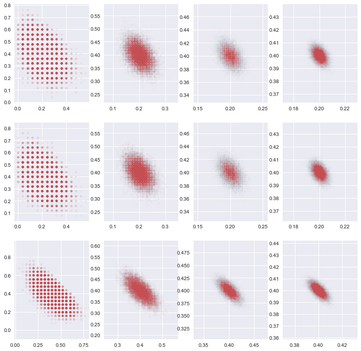

```python
ns=20000
nthrows = [25,  200,  1600, 12800]
probvec = np.asarray([.2,.4,.4])
#sm = []
#x = np.reshape(np.zeros(3*ns),(ns,3))
fig, ax = plt.subplots(nrows=3, ncols=len(nthrows),figsize=(12,12))
for i in range(len(nthrows)):
    sm=np.random.multinomial(nthrows[i],probvec,size=ns)/nthrows[i]
    ax[0][i].scatter(sm[:,0], sm[:,1],marker='.',c='r',alpha=.05/(i+1)**(2))
    ax[0][i].set_aspect(1,'datalim')
    ax[1][i].scatter(sm[:,0], sm[:,2],marker='.',c='r',alpha=.05/(i+1)**(2))
    ax[1][i].set_aspect(1,'datalim')
    ax[2][i].scatter(sm[:,1], sm[:,2],marker='.',c='r',alpha=.05/(i+1)**(2))
    ax[2][i].set_aspect(1,'datalim')
#    sm.append(x)
#print(sm.shape)
#plt.scatter(sm[:,0], sm[:,2],marker='.',c='r',alpha=.02)
```

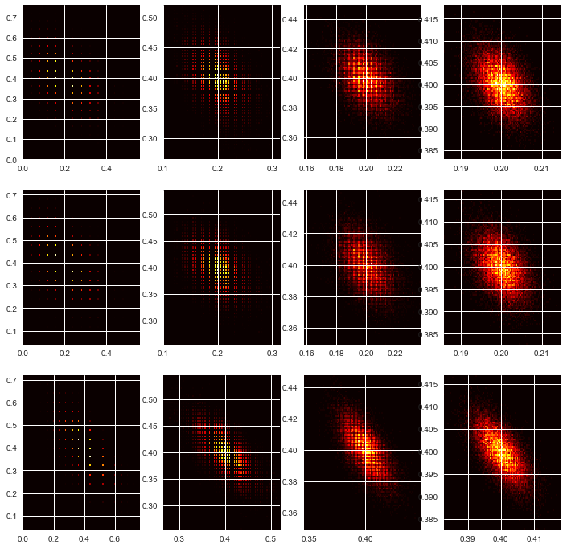

```python
ns=20000
nthrows = [25,  200,  1600, 12800]
probvec = np.asarray([.2,.4,.4])
#sm = []
#x = np.reshape(np.zeros(3*ns),(ns,3))
fig, ax = plt.subplots(nrows=3, ncols=len(nthrows),figsize=(12,12))
for i in range(len(nthrows)):
    sm=np.random.multinomial(nthrows[i],probvec,size=ns)/nthrows[i]
    ax[0][i].hist2d(sm[:,0], sm[:,1],bins=100,cmap='hot')
    ax[1][i].hist2d(sm[:,0], sm[:,2],bins=100,cmap='hot')
    ax[2][i].hist2d(sm[:,1], sm[:,2],bins=100,cmap='hot')
```

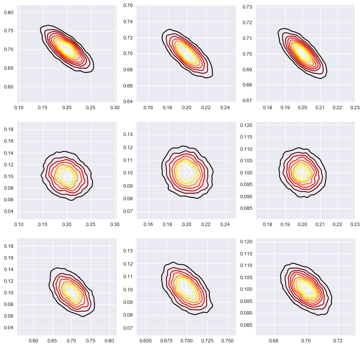

```python
ns=10000
nthrows = [250,  1000, 4000]
probvec = np.asarray([.2,.7,.1])
fig, ax = plt.subplots(nrows=3, ncols=len(nthrows),figsize=(12,12))
for i in range(len(nthrows)):
    sm=np.random.multinomial(nthrows[i],probvec,size=ns)/nthrows[i]
    sns.kdeplot(sm[:,0], sm[:,1],cmap='hot', ax=ax[0][i])
    sns.kdeplot(sm[:,0], sm[:,2],cmap='hot', ax=ax[1][i])
    sns.kdeplot(sm[:,1], sm[:,2],cmap='hot', ax=ax[2][i])
```

### Statement of CLT (univariate)

Let $X_1, \ldots, X_n$ be independent and identically distributed (i.i.d.) random variables with mean $\mu$ and variance $\sigma^2$. Let $\langle X\rangle_N=N^{-1}\sum_{i=1}^N X_i$. Then $$Z_N \triangleq \displaystyle\frac{\sqrt{N}\left(\langle X\rangle_N-\mu\right)}{\sigma} \approx Z,$$ where $Z\sim\mathcal{N}(0,1)$. This means, $$\displaystyle \lim_{N\rightarrow\infty} P(Z_N\leq z) = \mbox{CDF}(z) = \int_{-\infty}^z \frac{1}{\sqrt{2\pi}} e^{-x^2/2}\,dx.$$

### Statement of CLT (multivariate)

$$\left(\begin{array}{c}\langle X_1 \rangle_{N}\\\vdots\\\langle X_p \rangle_{N}\end{array}\right)=\frac{1}{N}\left(\begin{array}{c}\sum_{k=1}^N x_1^{(k)}\\\vdots\\\sum_{k=1}^N x_p^{(k)}\end{array}\right) $$ and the sample covariances, expressed in matrix form as $$\Sigma = \left(\begin{array}{ccc}\Sigma_{11}&\cdots&\Sigma_{1p}\\\vdots&\ddots&\vdots\\\Sigma_{p1}&\cdots&\Sigma_{pp}\end{array}\right), \; \Sigma_{ij} = \frac{1}{N-1} \sum_{k=1}^N \left(x_i^{(k)} - \langle X_i \rangle_{N}\right) \left(x_j^{(k)} - \langle X_j \rangle_{N}\right), \; i,j\in\{1,\ldots,p\}.$$

If the expectation (population mean) of each component $X_i$ is $\mu_i$, the spread of the scaled (by $\sqrt{N}$) sample means $\langle X_i\rangle_N$ around $\mu_i$ converges in distribution to a multivariate normal (Gaussian) distribution: $$ \sqrt{N}\left(\langle X_i\rangle_N^{(s)} - \mu_i\right)\approx \mathcal{N}(\boldsymbol{0}, \Sigma). $$

## Exercise

Match the multivariate Gaussian distribution with the sample means of the multinomial samples that you generated. You will need the means and variances of the multinomial (defined above) to obtain the means and variances of the Gaussian.